# Price Prediction Challenge

In this project, you are given a dataset of real-estate properties, and we ask you to develop code that predicts the list price of a property. You should have in mind that the price of each property may change a lot given its region, and your solution should take that into account (try some feature engineering).

For the solution, we request that you build at least 2 models for price prediction, and after evaluating each model, you should compare them to choose the best one for the task (use the mean absolute percentage error for comparison).

## Step by Step

- Understanding the dataset
- Filter the dataset, remove unused, inconsistent and outliers values.
- Visualizing the dataset
- Choose 4 models from different categories (Machine Learning)
- Evaluation of models
- Conclusion

```python
# data analysis and wrangling
import pandas as pd
import numpy as np
import random as rnd
from pyzipcode import Pyzipcode as pz
import json

# visualization
import seaborn as sns
import matplotlib.pyplot as plt
%matplotlib inline
```

```python
# import dataset
df = pd.read_csv('properties.csv')
print(df.columns.values)
```

```
['apn' 'zip_code' 'property_type' 'lot' 'sqft' 'beds' 'baths' 'price']
```

### Undestend dataset

Dataset Description

- The dataset is extracted from a real world real-estate database and its features are respectively:
- apn : identification code for a given property.
- zip_code : area code of a given property.
- property_type : type of the property; consider only the properties with property_type = residential
- lot : area of the lot
- sqft : square footage.
- beds : number of bedrooms
- baths : number of bathrooms, this value can be a float, because there are 3 types of bathrooms, each one represented by 0.5, 0.75 and 1.0, and this feature is the sum of these values.
- price : price of property.

```python
df.info()
```

```
<class 'pandas.core.frame.DataFrame'>
RangeIndex: 88039 entries, 0 to 88038
Data columns (total 8 columns):
apn              88039 non-null object
zip_code         88039 non-null object
property_type    88039 non-null object
lot              88039 non-null float64
sqft             88039 non-null float64
beds             88039 non-null int64
baths            88039 non-null float64
price            88039 non-null int64
dtypes: float64(3), int64(2), object(3)
memory usage: 5.4+ MB
```

```python
df.head()
```

|  | apn | zip_code | property_type | lot | sqft | beds | baths | price |
| --- | --- | --- | --- | --- | --- | --- | --- | --- |
| 0 | 06037-5782020007 | 91007 | residential | 20492.0 | 2991.0 | 4 | 2.5 | 2168000 |
| 1 | 06037-5436013020 | 90039 | residential | 6752.0 | 1533.0 | 3 | 2.0 | 898000 |
| 2 | 06037-2549013007 | 91040 | residential | 38757.0 | 3146.0 | 4 | 4.0 | 998999 |
| 3 | 06059-03318106 | 92831 | residential | 6375.0 | 1364.0 | 3 | 1.0 | 549000 |
| 4 | 06059-93279051 | 92637 | residential | 1700.0 | 1592.0 | 3 | 2.0 | 699999 |

```python
df.describe()
```

|  | lot | sqft | beds | baths | price |
| --- | --- | --- | --- | --- | --- |
| count | 8.803900e+04 | 8.803900e+04 | 88039.000000 | 88039.000000 | 8.803900e+04 |
| mean | 8.443710e+04 | 2.163834e+03 | 3.211917 | 2.481792 | 3.910071e+05 |
| std | 8.234011e+06 | 8.764446e+04 | 1.081260 | 3.227061 | 9.602470e+05 |
| min | 0.000000e+00 | 0.000000e+00 | 0.000000 | 0.000000 | 0.000000e+00 |
| 25% | 0.000000e+00 | 1.192000e+03 | 3.000000 | 2.000000 | 1.450000e+05 |
| 50% | 2.100000e-01 | 1.650000e+03 | 3.000000 | 2.000000 | 2.550000e+05 |
| 75% | 1.896000e+00 | 2.343000e+03 | 4.000000 | 3.000000 | 4.350000e+05 |
| max | 2.073238e+09 | 2.600270e+07 | 30.000000 | 900.000000 | 1.299000e+08 |

Min values of lot, sqft, beds, baths and price is zero.. A house does not have bathrooms or bedrooms can even exist, but the price, lot or sqft zeros, I believe are wrong records or trash.

```python
df.describe(include=['O'])
```

|  | apn | zip_code | property_type |
| --- | --- | --- | --- |
| count | 88039 | 88039 | 88039 |
| unique | 81054 | 10781 | 3 |
| top | 29165-999999 | 92677 | residential |
| freq | 35 | 258 | 83554 |

### Filter the dataset, remove unused, inconsistent and outliers values.

Filter only residential register type and drop unecessary columns

```python
# filter only residential
df = df[df['property_type'] == 'residential']

# drop unnecessary columns, these columns won't be useful in analysis and prediction
df = df.drop(['apn','property_type'], axis=1)
```

Remove registers sqft and price with zero values. Remove zip_code empty too.

```python
# Not necessery remove 'lot', because this value will not be used. Low correlation
#df = df[df['lot'] > 0.1]

# remove sqft zero
df = df[df['sqft'] > 0.1]

# remove price zero
df = df[df['price'] > 0.1]

# Remove residential with zipcode null
df = df[df['zip_code'].notnull()]

# Converto all to float
df['beds'] = df['beds'].astype(float)
df['price'] = df['price'].astype(float)
```

Remove outliers values, values with greater than 3x standard deviation. This process is useful for removing values out of the analysis, avoiding negative effects. It may be typing error or even unusual values

```python
for var in ['baths', 'beds', 'sqft', 'price']:
    df = df[df[var] < df[var].mean()+3*df[var].std()]
```

#### Converts postal code to coordinate latitude and longitude

```python
# Zip codes
df_zip = pd.read_csv("zipcod_to_cord.txt")

def zipcode_to_lat_lng(zipcode):
    zipnum = int(zipcode.split("-")[0])
    line = df_zip[df_zip['ZIP'] == zipnum]
    if len(line) > 0:
        return [line.LAT.values[0], line.LNG.values[0]]
    else:
        return [None, None]
```

```python
df['lat'] = df['zip_code'].apply(lambda x: zipcode_to_lat_lng(x)[0])
df['lng'] = df['zip_code'].apply(lambda x: zipcode_to_lat_lng(x)[1])
```

```python
# Remove residential with lat or lng is null
df = df[df['lng'].notnull()]
```

```python
print("Total dataset now:", len(df))
```

```
Total dataset now: 77069
```

### Visualizing the dataset

```python
df.head()
```

|  | zip_code | lot | sqft | beds | baths | price | lat | lng |
| --- | --- | --- | --- | --- | --- | --- | --- | --- |
| 0 | 91007 | 20492.0 | 2991.0 | 4.0 | 2.5 | 2168000.0 | 34.128284 | -118.047732 |
| 1 | 90039 | 6752.0 | 1533.0 | 3.0 | 2.0 | 898000.0 | 34.111885 | -118.261033 |
| 2 | 91040 | 38757.0 | 3146.0 | 4.0 | 4.0 | 998999.0 | 34.261962 | -118.336078 |
| 3 | 92831 | 6375.0 | 1364.0 | 3.0 | 1.0 | 549000.0 | 33.879768 | -117.896340 |
| 4 | 92637 | 1700.0 | 1592.0 | 3.0 | 2.0 | 699999.0 | 33.612925 | -117.731443 |

Histogram is a good way to visualize the distribution of data

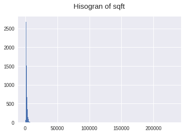

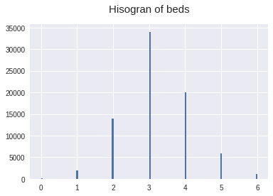

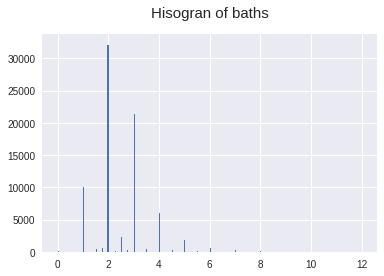

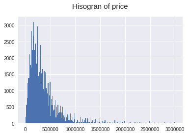

```python
for var in ['sqft', 'beds', 'baths', 'price']:
    # histogran
    plt.figure()
    plt.title('Hisogran of {}'.format(var), y=1.05, size=15)
    plt.hist(df[var].values, bins='auto')
    plt.plot()
```

#### Pearson Correlation Heatmap

let us generate some correlation plots of the features to see how related one feature is to the next. To do so, we will utilise the Seaborn plotting package which allows us to plot heatmaps very conveniently as follows

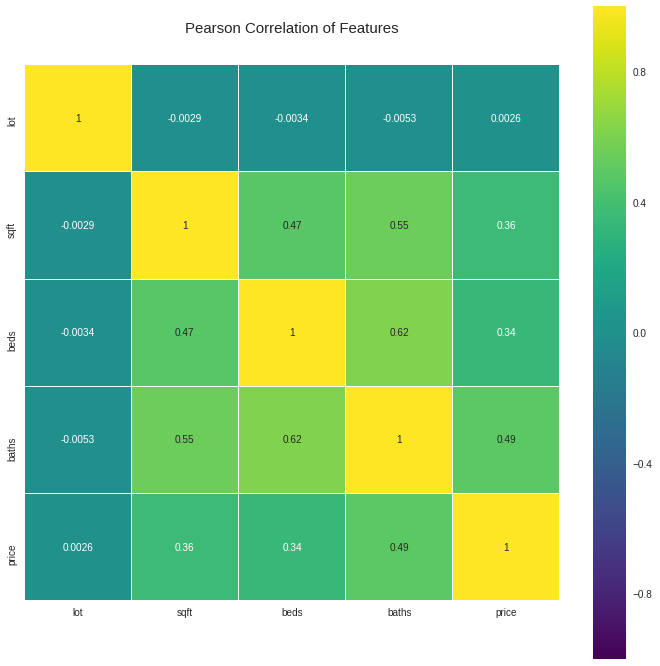

```python
colormap = plt.cm.viridis
plt.figure(figsize=(12,12))
plt.title('Pearson Correlation of Features', y=1.05, size=15)
sns.heatmap(df[['lot', 'sqft', 'beds', 'baths', 'price']]
            .astype(float).corr(),linewidths=0.1,vmax=1.0, square=True, cmap=colormap, linecolor='white', annot=True)
```

#### Plot Cordinates and Prices

```python
import folium
import datetime as dt

t0 = dt.datetime.now()

df_map = df.sample(5000)

# Build map
map_nyc = folium.Map(location=[df_map.iloc[1].lat, df_map.iloc[1].lng], zoom_start=5,
tiles='cartodbpositron', width=640, height=480)

# color
linear = folium.LinearColormap(['green', 'yellow', 'red'],
                           vmin=df_map.price.min(), vmax=df_map.price.max())


# Plot coordinates using comprehension list
for i in range(1, len(df_map)):
    folium.CircleMarker(location=[df_map.iloc[i].lat, df_map.iloc[i].lng],
                        radius=2, color=linear(df_map.iloc[i].price), fill_color=linear(df_map.iloc[i].price)).add_to(map_nyc)
#map_nyc.save('mapa.html')
t1 = dt.datetime.now()
print('Total time: %i seconds' % (t1 - t0).seconds)

map_nyc
```

```
Total time: 61 seconds
```

[interactive chart not shown]

```python
linear
```

[figure not shown]

### Choose 4 models from different categories (Machine Learning)

I chose a regions model (RandomForestRegressor and KNN), linear with LinearRegression and nolinear with a MultiLayerPerceptron. The problem is a non-linear problem, Mainly by the variables latitude and longitude.

#### Machine Learning

```python
from sklearn.model_selection import train_test_split
from sklearn import linear_model
from sklearn import neighbors
from sklearn.ensemble import RandomForestRegressor
from sklearn.neural_network import MLPRegressor
from sklearn import preprocessing
```

```python
# funcoes
def plot_residuo(residuo):
    plt.scatter([x for x in range(0,len(residuo))], residuo)
```

```python
# Scores model
score = {}
```

#### Split dataset in train and test

Split dataset to TRAIN (70%) and TEST (30%) data

```python
# Split 30% for test
X_train, X_test, y_train, y_test = train_test_split(df[['lat', 'lng', 'sqft', 'beds', 'baths']]
                                                    ,df.price, test_size=0.30, random_state=42)
```

```python
len(X_train)
```

```
53948
```

```python
len(X_test)
```

```
23121
```

#### Normalized

Normalize dataset with StandardScaler. Is necessary for the proper functioning of some algorithms

```python
scaler = preprocessing.StandardScaler().fit(X_train)

t_X_train = scaler.transform(X_train)
t_X_test = scaler.transform(X_test)
```

#### Linear Regression

```python
# Create linear regression object
model1 = linear_model.LinearRegression(normalize=False)
```

```python
# Train the model using the training sets
model1.fit(t_X_train, y_train)
```

```
LinearRegression(copy_X=True, fit_intercept=True, n_jobs=1, normalize=False)
```

```python
# The mean squared error
print("Mean squared error: %.2f" % np.mean((model1.predict(t_X_test) - y_test) ** 2))

# Explained variance score: 1 is perfect prediction
score['linear'] = model1.score(t_X_test, y_test)
print('Variance score: %.2f' % score['linear'])
```

```
Mean squared error: 71809799289.53
Variance score: 0.40
```

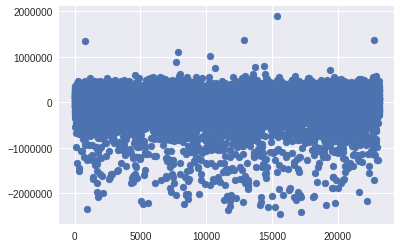

```python
# Plot residuo
plot_residuo(model1.predict(t_X_test) - y_test)
```

#### KNN

```python
# Create nolinear regression object with knn
knn = neighbors.KNeighborsRegressor(10, weights='distance', metric='euclidean')

knn.fit(t_X_train, y_train)
```

```
KNeighborsRegressor(algorithm='auto', leaf_size=30, metric='euclidean',
          metric_params=None, n_jobs=1, n_neighbors=10, p=2,
          weights='distance')
```

```python
# The mean squared error
print("Mean squared error: %.2f" % np.mean((knn.predict(t_X_test) - y_test) ** 2))

# Explained variance score: 1 is perfect prediction
score['knn'] = knn.score(t_X_test, y_test)
print('Variance score: %.2f' % score['knn'])
```

```
Mean squared error: 39850180414.11
Variance score: 0.67
```

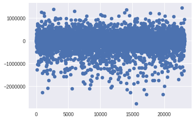

```python
plot_residuo(knn.predict(t_X_test) - y_test)
```

#### Random Forest Regressor

```python
forest = RandomForestRegressor(n_estimators=100)

forest.fit(t_X_train, y_train)
```

```
RandomForestRegressor(bootstrap=True, criterion='mse', max_depth=None,
           max_features='auto', max_leaf_nodes=None,
           min_impurity_split=1e-07, min_samples_leaf=1,
           min_samples_split=2, min_weight_fraction_leaf=0.0,
           n_estimators=100, n_jobs=1, oob_score=False, random_state=None,
           verbose=0, warm_start=False)
```

```python
# The mean squared error
print("Mean squared error: %.2f" % np.mean((forest.predict(t_X_test) - y_test) ** 2))

# Explained variance score: 1 is perfect prediction
score['RandomForest'] =  forest.score(t_X_test, y_test)
print('Variance score: %.2f' % score['RandomForest'])
```

```
Mean squared error: 23305154916.88
Variance score: 0.80
```

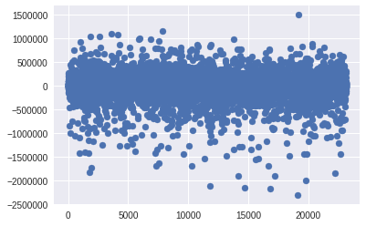

```python
plot_residuo(forest.predict(t_X_test) - y_test)
```

#### MLP

```python
# 50
mlp = MLPRegressor(hidden_layer_sizes=(75, 25), learning_rate='adaptive', verbose=True,
                   activation='relu', solver='lbfgs', max_iter=500)

mlp.fit(t_X_train, y_train)
```

```
MLPRegressor(activation='relu', alpha=0.0001, batch_size='auto', beta_1=0.9,
       beta_2=0.999, early_stopping=False, epsilon=1e-08,
       hidden_layer_sizes=(75, 25), learning_rate='adaptive',
       learning_rate_init=0.001, max_iter=500, momentum=0.9,
       nesterovs_momentum=True, power_t=0.5, random_state=None,
       shuffle=True, solver='lbfgs', tol=0.0001, validation_fraction=0.1,
       verbose=True, warm_start=False)
```

```python
# The mean squared error
print("Mean squared error: %.2f" % np.mean((mlp.predict(t_X_test) - y_test) ** 2))

# Explained variance score: 1 is perfect prediction
score['MLP'] = mlp.score(t_X_test, y_test)
print('Variance score: %.2f' % score['MLP'])
```

```
Mean squared error: 36749444379.85
Variance score: 0.69
```

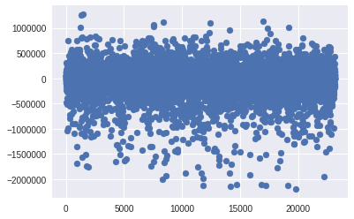

```python
plot_residuo(mlp.predict(t_X_test) - y_test)
```

```python
#plt.scatter(mlp.predict(t_X_test),  y_test)
```

### Evaluation of models

Plot Coefficient of determination (R2)

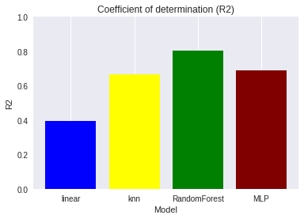

```python
import matplotlib.patches as mpatches

plt.rcParams['font.size'] = 14

fig, ax = plt.subplots(facecolor='w')

# Plot
plt.title("Coefficient of determination (R2)")
plt.xlabel('Model')
plt.ylabel('R2')
plt.legend()

lbl = score.keys()
y_pos = np.arange(len(lbl))
colors = ['b', 'yellow', 'g', 'maroon']

bar_locations = score.values()
plt.bar(np.arange(4), bar_locations, color=colors)

ax.set_xticks(y_pos)
ax.set_xticklabels(lbl)

axes = plt.gca()
axes.set_ylim([0,1])
ax.yaxis.grid()
```

```python
score
```

```
{'MLP': 0.69107432197650853,
 'RandomForest': 0.80409062216773886,
 'knn': 0.66500870389928646,
 'linear': 0.39634758270221981}
```

### Conclusion

The model that presented the best result was the RandoFlorest, mainly because it is an ensable and can be treated as a model of regions, very useful to map the nonlinearity presented by latitude and longitude coordinates. Knn also presented satisfactory results by the same principle. The worst model was the liner, it is clear that the relationship is non-linear, so a linear regression would never fit well to the data, it is possible to see the trend of the linear model by the residue report, to underestimate the price values.

Either way, a coefficient of determination of 80% for RandomForest is an acceptable result. But it is clear that the model still needs to be improved with other independent variables.